# Industry CAPM Regime Ambiguity

## Data

Data is imported from [Kenneth French's data library](http://mba.tuck.dartmouth.edu/pages/faculty/ken.french/data_library.html) and [FRED](https://fred.stlouisfed.org/series/). Currently, this workbook uses 49 industry portfolios and the FF4 factors. Additionally, NBER recession indicators complement the data.

## Model

### Theory

The rationale for the model goes as follows:

Let $r^i_{t}$ and $r^M_{t}$ denote excess returns on an asset $i$ and the market portfolio.

Investors use a standard CAPM to form expectations about means and variances of asset excess returns: $$\mathbb{E}_t\big[r^i_{t+1}\big] = \alpha^i + \beta^i \, \mathbb{E}_t\big[r^{M}_{t+1}\big]$$ $$\mathbb{V}_t\big[r^i_{t+1}\big] = (\sigma^i)^2$$

Now suppose agents are ambiguous about the set of model-parameters that are generating next-period returns. In particular, there are two competing sets of parameters $\theta^i_{S_{t+1}} = \big(\alpha^i_{S_{t+1}}, \beta^i_{S_{t+1}}, \sigma^i_{S_{t+1}}\big)$, where $S_{t+1} \in \{0,1\}$, and the transition between the two sets of parameters follows a Markov process:

\begin{equation*} \begin{cases} r^i_{t+1} = \alpha^i_{S_{t+1}=0} + \beta^i_{S_{t+1}=0} \, \mathbb{E}_t\big[r^M_{t+1}\big] + \varepsilon^i_{t+1}, \quad\quad \varepsilon^i_{t+1} \sim \mathcal{N}\big(0,(\sigma^i_{S_{t+1}=0})^2\big)\\ r^i_{t+1} = \alpha^i_{S_{t+1}=1} + \beta^i_{S_{t+1}=1} \, \mathbb{E}_t\big[r^M_{t+1}\big] + \varepsilon^i_{t+1}, \quad\quad \varepsilon^i_{t+1} \sim \mathcal{N}\big(0,(\sigma^i_{S_{t+1}=1})^2\big) \end{cases} \end{equation*}\begin{equation*} P\big(S^i_{t+1} = s^i_{t+1} \, \big| \, S^i_{t} = s^i_{t}\big) = \begin{bmatrix} p^i_{00} & 1-p^i_{00}\\ p^i_{10} & 1-p^i_{10}\\ \end{bmatrix} \end{equation*}

Given the two-regime markov process, investors are ambiguous between two Gaussian distributions that next-period returns could be drawn from: \begin{equation} \begin{cases} \phi_0(r^i_{t+1}) = \mathcal{N}\big(\mu^i_0 = \alpha^i_{0} + \beta^i_{0} \, \mathbb{E}_t\big[r^M_{t+1}\big],(\sigma^i_{0})^2\big), \quad \text{with probability } P_t(S^i_{t+1} = 0)\\ \phi_1(r^i_{t+1}) = \mathcal{N}\big(\mu^i_1 = \alpha^i_{1} + \beta^i_{1} \, \mathbb{E}_t\big[r^M_{t+1}\big],(\sigma^i_{1})^2\big), \quad \text{with probability } P_t(S^i_{t+1} = 1) = \big[1-P_t(S^i_{t+1} = 0)\big] \end{cases} \end{equation} For both distributions, $\beta^i_{S_{t+1}}$ reflects the state-dependent level of systematic risk, while $(\sigma^i_{S_{t+1}})^2$ denotes the asset's state-dependent level of idiosyncratic risk.

With knowledge of regime-probabilities at time $t$, next-period $t+1$ regime-probabilities are given by: \begin{equation*} \begin{bmatrix} P_t(S^i_{t+1} = 0)& P_t(S^i_{t+1} = 1)\\ \end{bmatrix}= \begin{bmatrix} P_t(S^i_{t} = 0)& P_t(S^i_{t} = 1)\\ \end{bmatrix} \begin{bmatrix} p^i_{00} & 1-p^i_{00}\\ p^i_{10} & 1-p^i_{10}\\ \end{bmatrix} \end{equation*}

Note that although both priors rely on normality assumptions, the weighted expectiation about the next-period return distribution (by probability-weighting the two priors) is no longer normal. Instead, it follows a mixture distribution $\mathcal{D}\big(\mu^i_D,(\sigma^i_D)^2,.\big)$ with first and second moments $\mu^i_D$ and $(\sigma^i_D)^2$, and finite higher moments: \begin{align} \mathbb{E}_t\big[\phi(r^i_{t+1})\big] &= P_t(S^i_{t+1} = 0) \times \phi_0(r^i_{t+1}) + \big[1-P_t(S^i_{t+1} = 0)\big] \times \phi_1(r^i_{t+1})\\ &= P_t(S^i_{t+1} = 0) \times \mathcal{N}\big(\mu^i_0,(\sigma^i_{0})^2\big) + \big[1-P(S^i_{t+1} = 0)\big] \times \mathcal{N}\big(\mu^i_1,(\sigma^i_{1})^2\big)\\ %&= N\big(P(S^i_{t+1} = 0) \times \big(\alpha^i_{0} + \beta^i_{0} \times \mathbb{E}_t\big[r^M_{t+1}\big]\big) + \big[1-P_t(S^i_{t+1} = 0)\big] \times \big(\alpha^i_{1} + \beta^i_{1} \times \mathbb{E}_t\big[r^M_{t+1}\big]\big), \quad P(S^i_{t+1} = 0) \times (\sigma^i_{0})^2 + \big[1-P_t(S^i_{t+1} = 0)\big] \times (\sigma^i_{0})^2 \big) %&= \mathcal{D}\big(P(S^i_{t+1} = 0) \times \big(\alpha^i_{0} + \beta^i_{0} \times \mathbb{E}_t\big[r^M_{t+1}\big]\big)+ \big[1-P(S^i_{t+1} = 0)\big] \times \big(\alpha^i_{1} + \beta^i_{1} \times \mathbb{E}_t\big[r^M_{t+1}\big]\big)\big)\\ %&= \mathcal{D}\big(\alpha^i_{w} + \beta^i_{w} \times \mathbb{E}_t\big[r^M_{t+1}\big]\big) &= \mathcal{D}\big(\mu^i_D,(\sigma^i_D)^2,.\big) \end{align}

The first two moments of $\mathcal{D}(.)$ are given by: \begin{align*} \mu^i_D &= \sum_{s_{t+1}=0}^{1} P_t(S^i_{t+1} = s_{t+1}) \times \mu^i_{s_{t+1}} &= \mathbb{E}_t\big[r^i_{t+1}\big] \\ (\sigma^i_D)^2 &= \sum_{s_{t+1}=0}^{1} P_t(S^i_{t+1} = s_{t+1}) \times (\sigma^i_{s_{t+1}})^2 + \sum_{s_{t+1}=0}^{1} P_t(S^i_{t+1} = s_{t+1}) \times (\mu^i_{s_{t+1}})^2 - \Big(\sum_{s_{t+1}=0}^{1} P_t(S^i_{t+1} = s_{t+1}) \times \mu^i_{s_{t+1}}\Big)^2 &= \mathbb{V}_t\big[r^i_{t+1}\big] \end{align*}

Note that these moments can be interpreted as the expected return and expected total variance of asset $i$'s return.

### Estimation

Empirically, we can estimate a Markov regime switching model in historical return data for each asset $i$. Intercept $\alpha^i_{S_t}$, market beta $\beta^i_{S_t}$ and error variance $(\sigma^i_{S_t})^2$ are state-dependent, while transition probabilities $p_{00}$ and $p_{10}$ are static. More formally:

\begin{equation*} r^i_t = \alpha^i_{S_t} + \beta^i_{S_t} \, r_t^M + \varepsilon^i_{t}, \quad\quad \varepsilon^i_{t} \sim \mathcal{N}\big(0,(\sigma^i_{S_t})^2\big), \quad\quad S_t \in \{0,1\} \end{equation*}\begin{equation*} P_{t-1}\big(S^i_{t} = s^i_{t} \, \big| \, S^i_{t-1} = s^i_{t-1}\big) = \begin{bmatrix} p^i_{00} & 1-p^i_{00}\\ p^i_{10} & 1-p^i_{10}\\ \end{bmatrix} \end{equation*}

The parameters $p^i_{00}, p^i_{10}, \alpha^i_0, \alpha^i_1, \beta^i_0, \beta^i_1, (\sigma^i_{1})^2, (\sigma^i_{2})^2$ and their standard errors are estimated by maximum likelihood. Restrictions of the general model such as $\alpha^i_0 = \alpha^i_1$ or $(\sigma^i_{0})^2 = (\sigma^i_{1})^2$ are possible, but for now we stick to the general model.

From the estimation, we also obtain smoothing probabilites to be in either regime for all in-sample periods.

I use 60 months of rolling monthly data to obtain estimates for each industry. Out of the 60 months in the window, I require 48 to have industry return data available. In addition, I also estimate a standard linear regression model for each asset and data window: $$r^i_t = \alpha^i+\beta^i \, r^M_t, \quad\quad \varepsilon^i_t \sim \mathcal{N}\big(0,(\sigma^i)^2\big)$$ This can serve as a benchmark and help distinguish periods in which there really were multiple possible regimes at work.

### Model Summary Statistics

#### Summary of regime-switching Models

To summarise the models let us first look at some descriptive statistics. A large share of the estimated models actually converged to a solution. The remaining models either reached the maximum number of iterations or encountered another error during the optimisation. The large number of models makes it impossible look at each model separately, but the overall convergence rate is sufficiently large to proceed with the analyis.

| Total models | 48800 |
| --- | --- |
| Total converged | 42842 |
| Convergence rate | 0.8779 |

Next, we can ask how different the two regimes really are on average. For that purpose, the table below contains the spreads between the parameter estimates under both regimes. In addition, we can test the statistical significance of the difference for each parameter pair using a two-sample t-statistic, e.g. for $H_0: \beta^i_0=\beta^i_1$: $$t_{[\beta^i_0=\beta^i_1]} = \frac{\beta^i_0-\beta^i_1}{\sqrt{\big[s.e.(\beta^i_0)\big]^2+\big[s.e.(\beta^i_1)\big]^2 - 2 \, cov(\beta^i_0,\beta^i_1)}}$$ The table reports mean and standard deviation of parameters spreads, and the percentage of test statistics being significant at the 95% level.

|  | mean spread | std spread | % significant at 95% |
| --- | --- | --- | --- |
| alpha | 2.1331 | 3.1237 | 0.4589 |
| beta | 0.8929 | 0.6503 | 0.8194 |
| sigma2 | 24.9934 | 59.5788 | 0.8558 |

To benchmark the regime-switching models, standard CAPM specifications with only one regime are estimated in the same data. The table below reports the frequency of cases where the Markov regime-switching models are preferred over the OLS specifications given various criteria. With eight free parameters instead of two, higher likelihood can easily be achieved. Therefore, better criteria take into account the number of parameters. Using an Akaike information criterion, in approximately half of the cases a two-regime specification achieves a better fit. If instead a Bayesian information criterion is used to select the model, only in a small number of cases the Markov model will be preferred.

|  | % HMM fits better than OLS |
| --- | --- |
| likelihood | 0.9964 |
| AIC | 0.4509 |
| BIC | 0.0788 |

If we compare the cross-sectional means of these statistics over time, we that there is time-series variation in how well the models match the data. However, the variation in the fit of the Hidden Markov Models (HMM) closely matches the variation of the OLS specifications. In periods where the HMM models do a relatively poorer job coincide with periods when standard one-regime CAPM regressions also have a decresed ability to explain returns.

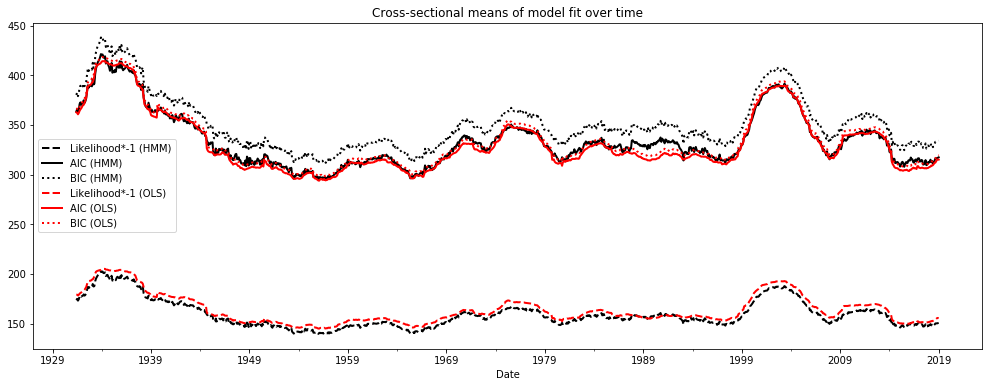

### Correlation analysis of estimates from various models

To further evaluate the usefulness of the Hidden Markov Models (HMM), we calculate correlations of parameter estimates of such models with their standard CAPM counterparts. In particular, we consider the following:

- **Mean HMM**: The Markov switching model estimates weighted at the mean probabilities of the two regimes over the observation window.
- **Last HMM**: The Markov switching model estimates weighted at the regime-probabilities in the last month in the observation window.
- **Expected HMM at t-1**: The Markov switching model estimates weighted at the regime-probabilities in the last month in the observation window, iterated forward by one month through the transition matrix.
- **CAPM**: OLS estimates from CAPM regressions in the same observation window as in the HMM case.
- **Realised**: OLS estimates from CAPM regressions using 1 month of daily data.

Below therere three comparisons reported in the table:

- **Mean HMM vs. CAPM**: The first sanity check for the HMM models is to compare their estimates with the one-regime case of the standard CAPM. To have a sensible comparison, regime-parameters are weighted at the probabilites over the respective sample. Full-sample estimates obtained in such a way are considerably correlated to the CAPM equivalents.
- **Last HMM vs. Realised**: Next, we can ask if the most recent monthly estimates for each model are correlated with actually realised values. For that purpose, we correlate probability-weighted estimates at the end of each sample with realised CAPM estimates from daily data within the respective month. Correlations in this comparison indicate that HMM models do reasonably well in describing parameters realised within a given month.
- **Expected HMM at t-1 vs. Realised**: Last, we examine the predictive ability of HMM models with regards to realised volatility in the subsequent month. Instead of using static regime-probabilities, we can iterate one period forward by using the transition matrix. Such predicted regime probabilities are obtained purely from historical data and can therefore serve as a 1-month forecast. Compared to the previous contemperaneous relation, risk estimates are still similarly strongly correlated, whereas there is no predictive relation with regards to alpha.

The numbers in the table are Pearson correlation coefficients calculated over all time periods and assets.

|  | CAPM | Realised |
| --- | --- | --- |
| Mean HMM α | 0.7828 |  |
| Mean HMM β | 0.9225 |  |
| Mean HMM σ² | 0.7165 |  |
| Last HMM α |  | 0.3145 |
| Last HMM β |  | 0.3850 |
| Last HMM σ² |  | 0.4621 |
| Expected HMM α (t-1) |  | 0.0381 |
| Expected HMM β (t-1) |  | 0.4383 |
| Expected HMM σ² (t-1) |  | 0.4249 |

## Ambiguity measurement

Given the two-regime process, a measure of (expected) ambiguity in such a setting chould take into account:

- The (second-order) probabilities of being in either regime
- The distance between the two regime prior distributions

### Regime-Probabilities

Regarding the probabilities, we can obtain a proxy of ambiguity by considering the dispersion of regime probabilities. If we assume that the agents' perceived ambiguity is related to the uncertainty of being in either of the two regimes, we can construct a measure of ambiguity based on the estimated next-period probabilities of being in either of the states. In this framework, maximum ambiguity is reached when the two states are equally likely (p=0.5). On the other hand there is no ambiguity if all the probability mass is on one state (either p=0 or p=1). Therefore, measures could be:

- The L2-distance to the point of equal probability, scaled between 0 and 1: $$\mathbb{D}_t\big[r^i_{t+1}\big] = 1-4 \, \big(P_t[S^i_{t+1} = 0]-0.5\big)^2$$
- Shannon entropy: $$\mathbb{H}_t\big[r^i_{t+1}\big] = -\sum^1_{s_{t+1}=0} P_t[S^i_{t+1} = s_{t+1}] * log_2\big(P_t[S^i_{t+1} = s_{t+1}]\big)$$

Both measures take a value of one if both states are equally likely (maximum ambiguity), and zero if there is no ambiguity about the next period return distribution. Hence they take very similar values.

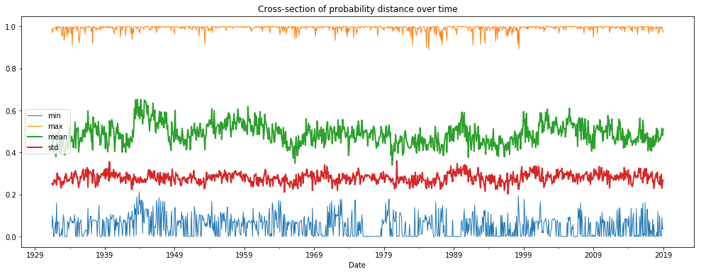

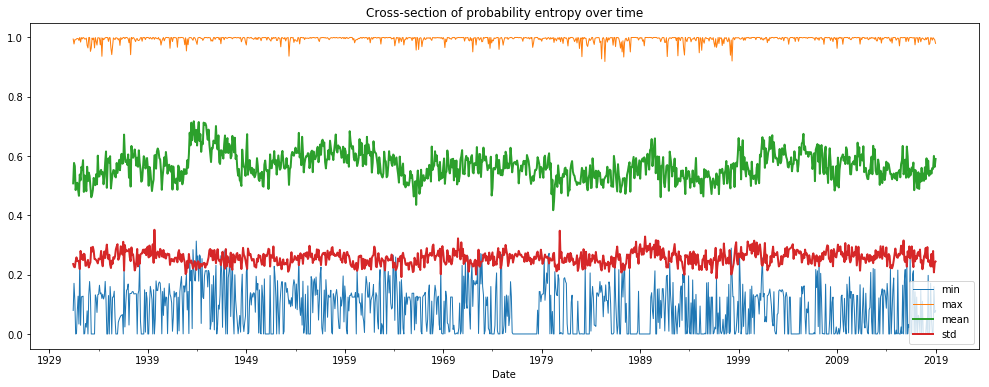

### Regime-Dispersion

Regarding the distance between the two priors, we can calculate a distance measure between probability distributions, e.g:

- Kolmogorov-Smirnov distance: $$\mathbb{KS}_t\big[r^i_{t+1}\big] = \sup_{r^i_{t+1}}\Big|\Phi_0(r^i_{t+1})-\Phi_1(r^i_{t+1})\Big| \quad \text{, where $\Phi(.)$ denotes the normal cumulative density function}$$
- Malalanobis distance (Bregman divergence): $$\mathbb{M}_t\big[r^i_{t+1}\big] = \sqrt{\frac{(\mu^i_0-\mu^i_1)^2}{\frac{(\sigma^i_0)^2+(\sigma^i_1)^2}{2}}}$$
- Kullback-Leibler divergence (relative entropy): $$\mathbb{R}_t\big[r^i_{t+1}\big] = ln\frac{\sigma^i_1}{\sigma^i_0} + \frac{(\sigma^i_0)^2+(\mu^i_0-\mu^i_1)^2}{2(\sigma^i_1)^2}-\frac{1}{2}$$

In order to parametrise the probability distributions (i.e. $\mu^i_{s_{t+1}}$ and $\sigma^i_{s_{t+1}}$), the previous estimates are used in combination with the full-sample average of the excess return on the market portfolio (as $\mathbb{E}_t\big[r^M_{t+1}\big]$).

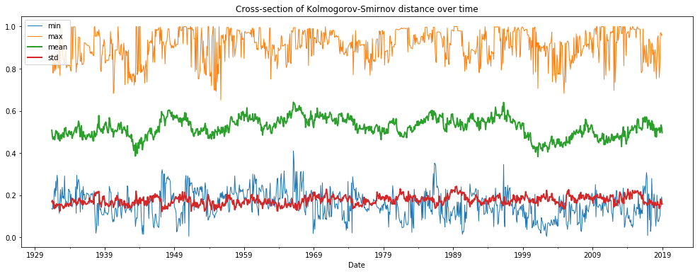

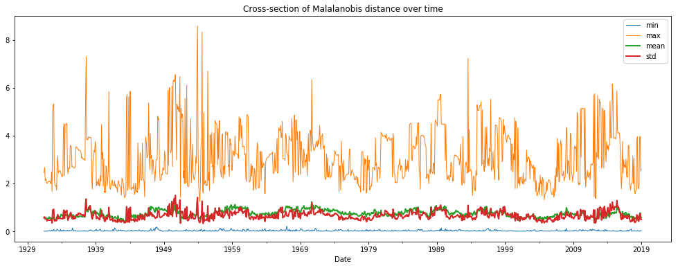

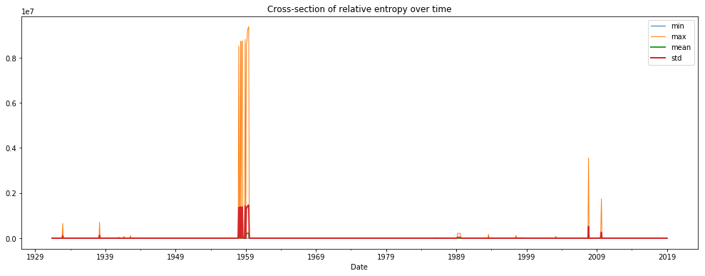

Note: Since relative entropy is not bounded from above, it takes some very large values in a few periods where parameters under one regime converge to extreme values. More, relative entropy is probably unsuitable since it is not symetric (it changes if the order of distributions changes).

### Measure Comparison

#### Summary Statistics

The following table is calculated using all observations across assets and time periods.

|  | D | H | KS | M | R | D x KS | D x M | D x R | H x KS | H x M | H x R |
| --- | --- | --- | --- | --- | --- | --- | --- | --- | --- | --- | --- |
| count | 42842.0000 | 42842.0000 | 42842.0000 | 42842.0000 | 42842.0000 | 42842.0000 | 42842.0000 | 42842.0000 | 42842.0000 | 42842.0000 | 42842.0000 |
| mean | 0.4881 | 0.5662 | 0.5216 | 0.7453 | 2313.1199 | 0.2401 | 0.3637 | 230.4958 | 0.2824 | 0.4212 | 382.5588 |
| std | 0.2813 | 0.2591 | 0.1802 | 0.6937 | 137124.7802 | 0.1496 | 0.4250 | 15190.2956 | 0.1470 | 0.4525 | 23650.9487 |
| min | 0.0000 | 0.0000 | 0.0040 | 0.0000 | 0.0001 | 0.0000 | 0.0000 | 0.0000 | 0.0000 | 0.0000 | 0.0000 |
| 25% | 0.2531 | 0.3580 | 0.3979 | 0.2626 | 0.8552 | 0.1336 | 0.0856 | 0.3810 | 0.1832 | 0.1148 | 0.4790 |
| 50% | 0.4358 | 0.5420 | 0.5207 | 0.5724 | 1.5598 | 0.2106 | 0.2161 | 0.7088 | 0.2616 | 0.2759 | 0.8653 |
| 75% | 0.7196 | 0.7870 | 0.6443 | 1.0078 | 2.7942 | 0.3190 | 0.4787 | 1.0732 | 0.3624 | 0.5585 | 1.3256 |
| max | 1.0000 | 1.0000 | 1.0000 | 8.5863 | 9377634.4163 | 0.9936 | 4.8623 | 2377307.0830 | 0.9941 | 4.8644 | 3288065.5312 |

Where:

- **D**: L2-distance
- **H**: Shannon entropy
- **KS**: Kolmogorov-Smirnov distance
- **M**: Malalanobis distance
- **R**: Relative entropy

Turning to summary statistics, we can confirm that relative entropy is in undesirable candidate for a measure. Another thing to point out here is that, while the variation in KS has a similar magnitude as D and H, the measure M varies a lot more and therefore dominates interactions.

#### Correlations

Given the similarity of some of the measures, we next look at correlations across measures of regime-probability dispersion, regime disperion, and interactions. Correlations are calculated using the full time-series and the full-cross-section.

|  | D | H | KS | M | R | D x KS | D x M | D x R | H x KS | H x M | H x R |
| --- | --- | --- | --- | --- | --- | --- | --- | --- | --- | --- | --- |
| D | 1.0000 | 0.9952 | -0.2858 | -0.0005 | -0.0233 | 0.7648 | 0.5095 | -0.0181 | 0.6749 | 0.4389 | -0.0201 |
| H |  | 1.0000 | -0.2761 | -0.0042 | -0.0261 | 0.7695 | 0.5045 | -0.0197 | 0.6891 | 0.4383 | -0.0220 |
| KS |  |  | 1.0000 | 0.7313 | 0.0388 | 0.3034 | 0.4237 | 0.0341 | 0.4310 | 0.4980 | 0.0366 |
| M |  |  |  | 1.0000 | 0.0387 | 0.4163 | 0.7228 | 0.0356 | 0.4886 | 0.7977 | 0.0378 |
| R |  |  |  |  | 1.0000 | -0.0167 | -0.0051 | 0.8107 | -0.0148 | -0.0011 | 0.8853 |
| D x KS |  |  |  |  |  | 1.0000 | 0.8373 | -0.0103 | 0.9860 | 0.7997 | -0.0122 |
| D x M |  |  |  |  |  |  | 1.0000 | -0.0002 | 0.8410 | 0.9911 | -0.0013 |
| D x R |  |  |  |  |  |  |  | 1.0000 | -0.0074 | 0.0042 | 0.9899 |
| H x KS |  |  |  |  |  |  |  |  | 1.0000 | 0.8208 | -0.0095 |
| H x M |  |  |  |  |  |  |  |  |  | 1.0000 | 0.0031 |
| H x R |  |  |  |  |  |  |  |  |  |  | 1.0000 |

Where:

- **D**: L2-distance
- **H**: Shannon entropy
- **KS**: Kolmogorov-Smirnov distance
- **M**: Malalanobis distance
- **R**: Relative entropy

With a correlation above 0.99, the choice between D and H is a pure matter of preference. Given the outlier-driven structure of R, the distance between regimes should be described by either KS or M. Both are again highly correlated, whereas M appears to be more independent from the measures of probability dispersion and dominates them when interacted due to its larger variation.

### Ambiguity proxy

Taking into account both components (probabilities and distributions), we can create a combined measure by interacting the two. This will be the proxy for ambiguity in what follows. Given the property that both measures are bounded between 0 and 1 and the evidence from the previous part, a combination of the L2-distance and the Kolmogorov-Smirnov distance currently serves as ambiguity proxy: $$\mathbb{A}_t\big[r^i_{t+1}\big] = \mathbb{D}_t\big[r^i_{t+1}\big] \times \mathbb{KS}_t\big[r^i_{t+1}\big]$$

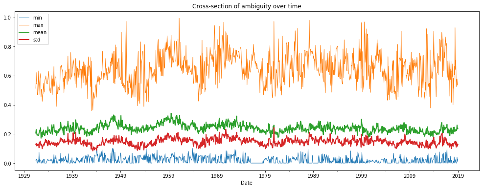

## Analysis

### Pooled Regression

To establish whether the ambiguity measure predicts returns on the subsequent period, we run pooled regressions of the following form: $$ r_{t+1}^i = \beta_0 + \beta_1 \, \mathbb{A}_t\big[r^i_{t+1}\big] + \gamma \, X^i_t + \varepsilon_{t+1}^i $$

First, we consider total regime ambiguity $\mathbb{A}_t\big[r^i_{t+1}\big]$ as the independent variable of interest. We can then also consider the contributors probability distance $\mathbb{D}_t\big[r^i_{t+1}\big]$ and Kolmogorov-Smirnov distance $\mathbb{KS}_t\big[r^i_{t+1}\big]$ separately to decompose the effects in alternative specifications.

$X^i_t$ is a set of conditioning variables. After considering univariate regressions of returns on ambiguity as depicted in the scatter plot below, we include the expected first two moments of the mixed prior distribution to contrast the effect of ambiguity with that of risk. These expected moments incorporate the expected parameters obtained from the Markov chain of regime probabilities. In another specification we can also directly include expected $\alpha$, $\beta$ and $\sigma^2$. Additionally, the Akaike information criterion of the corresponding two-regime model serves to control for misspecified models. Lastly, we condition on estimates from intra-month CAPM regressions to account for standard CAPM risk metrics.

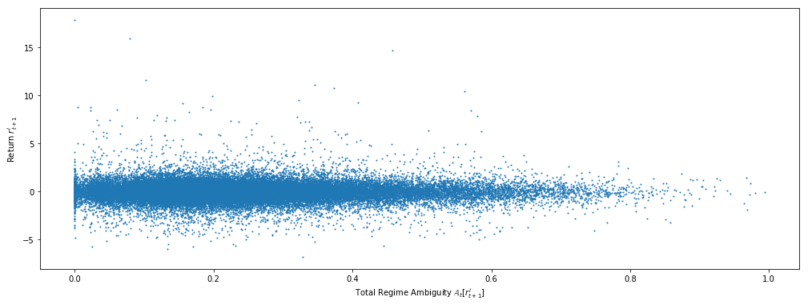

Below are parameter estimates and standard errors (White) from a various regression specifications. Variables in the regressions are cross-sectionally standardised.

It seems that the effect of ambiguity mainly stems from second-order probabilities, and the contribution of regime dispersion is weak. Conditioning on various sets of variables appears not to significantly impact the negative predictive relation of expected return ambiguity and returns.

|  | 1 | 2 | 3 | 4 | 5 | 6 | 7 | 8 | 9 | 10 | 11 | 12 |
| --- | --- | --- | --- | --- | --- | --- | --- | --- | --- | --- | --- | --- |
| constant | -0.0007 | -0.0007 | -0.0007 | -0.0001 | -0.0007 | -0.0007 | -0.0007 | -0.0001 | -0.0007 | -0.0007 | -0.0007 | -0.0001 |
|  | 0.0046 | 0.0046 | 0.0046 | 0.0047 | 0.0046 | 0.0046 | 0.0046 | 0.0047 | 0.0046 | 0.0046 | 0.0046 | 0.0047 |
| $\mathbb{A}_t[r^i_{t+1}]$ | -0.0095 | -0.0113 | -0.0107 | -0.0101 |  |  |  |  |  |  |  |  |
|  | 0.0048 | 0.0047 | 0.0049 | 0.0048 |  |  |  |  |  |  |  |  |
| $\mathbb{D}_t[r^i_{t+1}]$ |  |  |  |  | -0.0080 | -0.0093 | -0.0106 | -0.0083 |  |  |  |  |
|  |  |  |  |  | 0.0046 | 0.0047 | 0.0049 | 0.0047 |  |  |  |  |
| $\mathbb{KS}_t[r^i_{t+1}]$ |  |  |  |  |  |  |  |  | -0.0007 | -0.0012 | 0.0005 | -0.0014 |
|  |  |  |  |  |  |  |  |  | 0.0046 | 0.0046 | 0.0047 | 0.0046 |
| $\mathbb{E}_t[r^i_{t+1}]$ |  | 0.0130 |  |  |  | 0.0129 |  |  |  | 0.0133 |  |  |
|  |  | 0.0072 |  |  |  | 0.0072 |  |  |  | 0.0072 |  |  |
| $\mathbb{V}_t[r^i_{t+1}]$ |  | 0.0179 |  |  |  | 0.0176 |  |  |  | 0.0167 |  |  |
|  |  | 0.0133 |  |  |  | 0.0134 |  |  |  | 0.0133 |  |  |
| expected α$_{t+1}$ |  |  | 0.0146 |  |  |  | 0.0145 |  |  |  | 0.0145 |  |
|  |  |  | 0.0071 |  |  |  | 0.0071 |  |  |  | 0.0071 |  |
| expected β$_{t+1}$ |  |  | -0.0064 |  |  |  | -0.0074 |  |  |  | -0.0055 |  |
|  |  |  | 0.0056 |  |  |  | 0.0057 |  |  |  | 0.0056 |  |
| expected σ$^2_{t+1}$ |  |  | 0.0248 |  |  |  | 0.0243 |  |  |  | 0.0252 |  |
|  |  |  | 0.0154 |  |  |  | 0.0154 |  |  |  | 0.0153 |  |
| AIC |  |  | -0.0050 |  |  |  | -0.0035 |  |  |  | -0.0062 |  |
|  |  |  | 0.0090 |  |  |  | 0.0091 |  |  |  | 0.0090 |  |
| realised α$_t$ |  |  |  | 0.0243 |  |  |  | 0.0243 |  |  |  | 0.0243 |
|  |  |  |  | 0.0082 |  |  |  | 0.0082 |  |  |  | 0.0082 |
| realised β$_t$ |  |  |  | 0.0098 |  |  |  | 0.0094 |  |  |  | 0.0098 |
|  |  |  |  | 0.0065 |  |  |  | 0.0066 |  |  |  | 0.0066 |
| realised σ$^2_t$ |  |  |  | 0.0333 |  |  |  | 0.0333 |  |  |  | 0.0327 |
|  |  |  |  | 0.0234 |  |  |  | 0.0234 |  |  |  | 0.0234 |
| R² | 0.0001 | 0.0007 | 0.0009 | 0.0013 | 0.0001 | 0.0007 | 0.0009 | 0.0012 | 0.0000 | 0.0006 | 0.0008 | 0.0011 |
| N | 42773 | 42773 | 42773 | 42771 | 42773 | 42773 | 42773 | 42771 | 42773 | 42773 | 42773 | 42771 |

### Portfolio Sorts

#### Single Sorts

Portfolios are sorted based on the combined ambiguity measure, where Portfolio '1' is the low-ambiguity portfolio. Period-asset pairs where a simple one-regime CAPM has a better fit than the two-regime CAPM based on the AIC criterion are excluded from the sorts.

Although the high-minus-low ambuguity portfolio has a negative return consistent with the previous section, it only returns about 1% per year and its return is not significant using a regular standard errors.

|  | mean | std | T | average N | t-stat | return p.a. | volatility p.a. | SR |
| --- | --- | --- | --- | --- | --- | --- | --- | --- |
| 1 | 0.9126 | 6.2963 | 1051 | 3.5300 | 4.6991 | 10.9516 | 21.8109 | 0.5021 |
| 2 | 0.9802 | 6.3536 | 1051 | 3.5214 | 5.0014 | 11.7622 | 22.0095 | 0.5344 |
| 3 | 0.7307 | 6.2325 | 1051 | 3.5442 | 3.8010 | 8.7687 | 21.5900 | 0.4061 |
| 4 | 0.7978 | 6.0887 | 1051 | 3.5214 | 4.2478 | 9.5734 | 21.0919 | 0.4539 |
| 5 | 0.8299 | 6.7409 | 1051 | 3.5300 | 3.9913 | 9.9589 | 23.3511 | 0.4265 |
| 5-1 | -0.0827 | 3.9872 | 1051 |  | -0.6726 | -0.9927 | 13.8122 | -0.0719 |

#### Double Sorts

Portfolios are sorted first on expected betas, then on ambiguity. Period-asset pairs where a simple one-regime CAPM has a better fit than the two-regime CAPM based on the AIC criterion are excluded from the sorts.

For example, portfolio *'1,3'* refers to the low-beta, high-ambiguity portfolio.

Although returns on the spreading portfolios do not turn statistically significant when double-sorted, the pattern of increasing return spread with increasing beta is visible.

|  | mean | std | T | average N | t-stat | return p.a. | volatility p.a. | SR |
| --- | --- | --- | --- | --- | --- | --- | --- | --- |
| 1,1 | 0.6864 | 5.3295 | 1051 | 1.9610 | 4.1751 | 8.2364 | 18.4621 | 0.4461 |
| 1,2 | 0.8709 | 5.4148 | 1050 | 1.9676 | 5.2117 | 10.4509 | 18.7576 | 0.5572 |
| 1,3 | 0.7485 | 5.5630 | 1051 | 1.9610 | 4.3618 | 8.9817 | 19.2708 | 0.4661 |
| 2,1 | 0.9794 | 6.6113 | 1051 | 1.9610 | 4.8026 | 11.7529 | 22.9022 | 0.5132 |
| 2,2 | 0.7734 | 6.5551 | 1048 | 1.9552 | 3.8195 | 9.2808 | 22.7075 | 0.4087 |
| 2,3 | 0.9397 | 6.9867 | 1051 | 1.9610 | 4.3602 | 11.2762 | 24.2027 | 0.4659 |
| 3,1 | 1.0843 | 7.9293 | 1051 | 1.9610 | 4.4332 | 13.0117 | 27.4679 | 0.4737 |
| 3,2 | 0.8611 | 8.2212 | 1050 | 1.9676 | 3.3941 | 10.3333 | 28.4790 | 0.3628 |
| 3,3 | 0.7857 | 8.5994 | 1051 | 1.9610 | 2.9619 | 9.4279 | 29.7893 | 0.3165 |
| 1,3 - 1,1 | 0.0621 | 4.2090 | 1051 |  | 0.4783 | 0.7452 | 14.5805 | 0.0511 |
| 2,3 - 2,1 | -0.0397 | 4.8568 | 1051 |  | -0.2652 | -0.4767 | 16.8245 | -0.0283 |
| 3,3 - 3,1 | -0.2986 | 5.9798 | 1051 |  | -1.6191 | -3.5838 | 20.7145 | -0.1730 |

The same pattern repeats when using double-sorts based on expected variance and expected ambiguity.

(Note: Portfolio *'1,3'* now refers to the low-variance, high-ambiguity portfolio)

|  | mean | std | T | average N | t-stat | return p.a. | volatility p.a. | SR |
| --- | --- | --- | --- | --- | --- | --- | --- | --- |
| 1,1 | 0.7311 | 5.4502 | 1051 | 1.9610 | 4.3489 | 8.7735 | 18.8802 | 0.4647 |
| 1,2 | 0.6836 | 5.9676 | 1050 | 1.9676 | 3.7117 | 8.2028 | 20.6724 | 0.3968 |
| 1,3 | 0.7179 | 5.2250 | 1051 | 1.9610 | 4.4545 | 8.6152 | 18.1000 | 0.4760 |
| 2,1 | 0.9840 | 6.6912 | 1051 | 1.9610 | 4.7675 | 11.8081 | 23.1791 | 0.5094 |
| 2,2 | 0.7914 | 6.7377 | 1048 | 1.9552 | 3.8026 | 9.4973 | 23.3402 | 0.4069 |
| 2,3 | 0.9275 | 6.6992 | 1051 | 1.9610 | 4.4885 | 11.1303 | 23.2067 | 0.4796 |
| 3,1 | 1.0768 | 8.2939 | 1051 | 1.9610 | 4.2089 | 12.9212 | 28.7310 | 0.4497 |
| 3,2 | 0.7591 | 7.6580 | 1050 | 1.9676 | 3.2121 | 9.1095 | 26.5280 | 0.3434 |
| 3,3 | 0.9129 | 8.3275 | 1051 | 1.9610 | 3.5538 | 10.9545 | 28.8472 | 0.3797 |
| 1,3 - 1,1 | -0.0132 | 3.4188 | 1051 |  | -0.1251 | -0.1583 | 11.8431 | -0.0134 |
| 2,3 - 2,1 | -0.0565 | 4.5550 | 1051 |  | -0.4020 | -0.6778 | 15.7789 | -0.0430 |
| 3,3 - 3,1 | -0.1639 | 6.8424 | 1051 |  | -0.7765 | -1.9667 | 23.7028 | -0.0830 |

#### 4-Factor regressions

Finally, we regress the returns on the Ambiguity-minus-Pure-Risk-Portfolios (AMP) on standard return factors. Some of the coefficients are significant. However, loadings are relatively small and R² are generally low.

|  | AMP (all) | AMP (low beta) | AMP (medium beta) | AMP (high beta) | AMP (low variance) | AMP (medium variance) | AMP (high variance) |
| --- | --- | --- | --- | --- | --- | --- | --- |
| constant | -0.1072 | 0.0474 | -0.1356 | -0.3328 | 0.0165 | -0.0165 | -0.2081 |
|  | 0.1259 | 0.1341 | 0.1536 | 0.1901 | 0.1090 | 0.1454 | 0.2178 |
| Mkt-RF | -0.0181 | -0.0491 | -0.0377 | 0.0709 | -0.0597 | 0.0030 | -0.1018 |
|  | 0.0259 | 0.0276 | 0.0316 | 0.0391 | 0.0224 | 0.0299 | 0.0448 |
| SMB | 0.2244 | 0.1005 | 0.2286 | 0.0414 | -0.0063 | 0.0286 | 0.1529 |
|  | 0.0404 | 0.0430 | 0.0493 | 0.0610 | 0.0350 | 0.0467 | 0.0699 |
| HML | -0.0326 | 0.0870 | 0.1134 | -0.1705 | 0.0081 | -0.1251 | 0.0265 |
|  | 0.0383 | 0.0408 | 0.0467 | 0.0578 | 0.0332 | 0.0442 | 0.0663 |
| Mom | -0.0145 | -0.0200 | 0.0297 | 0.0698 | 0.0155 | -0.0010 | 0.1056 |
|  | 0.0295 | 0.0315 | 0.0360 | 0.0446 | 0.0256 | 0.0341 | 0.0511 |
| R² | 0.0303 | 0.0124 | 0.0271 | 0.0164 | 0.0101 | 0.0089 | 0.0139 |
| N | 1051.0000 | 1051.0000 | 1051.0000 | 1051.0000 | 1051.0000 | 1051.0000 | 1051.0000 |